# p8105_hw3_lmp2234

Lisa Pardee

2024-10-16

### Problem 1

#### Loading the necessary libraries

```r
library(p8105.datasets)
library(tidyverse)
library(janitor)
```

```r
library(dplyr)
library(lubridate)
library(ggplot2)
library(patchwork)
library(tidyr)
```

#### Reading in data and determining missing values

```r
data("ny_noaa")

sum(is.na(ny_noaa))
```

```
## [1] 3387623
```

```r
colSums(is.na(ny_noaa))
```

```
##      id    date    prcp    snow    snwd    tmax    tmin
##       0       0  145838  381221  591786 1134358 1134420
```

```r
total_obs<-nrow(ny_noaa)

missing_sum <-data.frame(
  variable = colnames(ny_noaa),
  missing_values = colSums(is.na(ny_noaa)),
  missing_percentage = (colSums(is.na(ny_noaa)) / total_obs) * 100 )

missing_sum<-missing_sum[missing_sum$missing_values >0, ]
missing_sum
```

```
##      variable missing_values missing_percentage
## prcp     prcp         145838            5.61958
## snow     snow         381221           14.68960
## snwd     snwd         591786           22.80331
## tmax     tmax        1134358           43.71025
## tmin     tmin        1134420           43.71264
```

The data set provides weather data and contains 2595176 observations and 7 variables.The variables named are weather station id (id), date of observation (date), precipitation (prcp) snowfall (snow), snow depth (snwd), maximum temperature (tmax), and minimum temperature (tmin). There is a total of 3387623 missing data values. The variables that have missing data are prcp, snow, snwd, tmax, and tmin. There is a very large portion of missing data for minimum and maximum data, and much missing data for snow and snwd. Overall, this dataset has a substantial portion of missing data.

#### Data Cleaning

```r
ny_noaa <- ny_noaa %>%
  clean_names() %>%
  mutate(
    prcp = as.numeric(prcp),
    tmax = as.numeric(tmax),
    tmin = as.numeric(tmin),
    snow = as.numeric(snow),
    snwd = as.numeric(snwd),
    year = year(ymd(date)),
    month = month(ymd(date)),
    day = day(date),
    prcp = prcp / 10,
    tmax = tmax / 10,
    tmin = tmin / 10
  )

snowfall_common <-ny_noaa %>%
  filter(snow>0) %>%
  count(snow)%>%
  arrange(snow)

top_n<-5

top_snowfall <- head(snowfall_common, n = top_n)
top_snowfall
```

```
## # A tibble: 5 × 2
##    snow     n
##   <dbl> <int>
## 1     3  8790
## 2     5  9748
## 3     8  9962
## 4    10  5106
## 5    13 23095
```

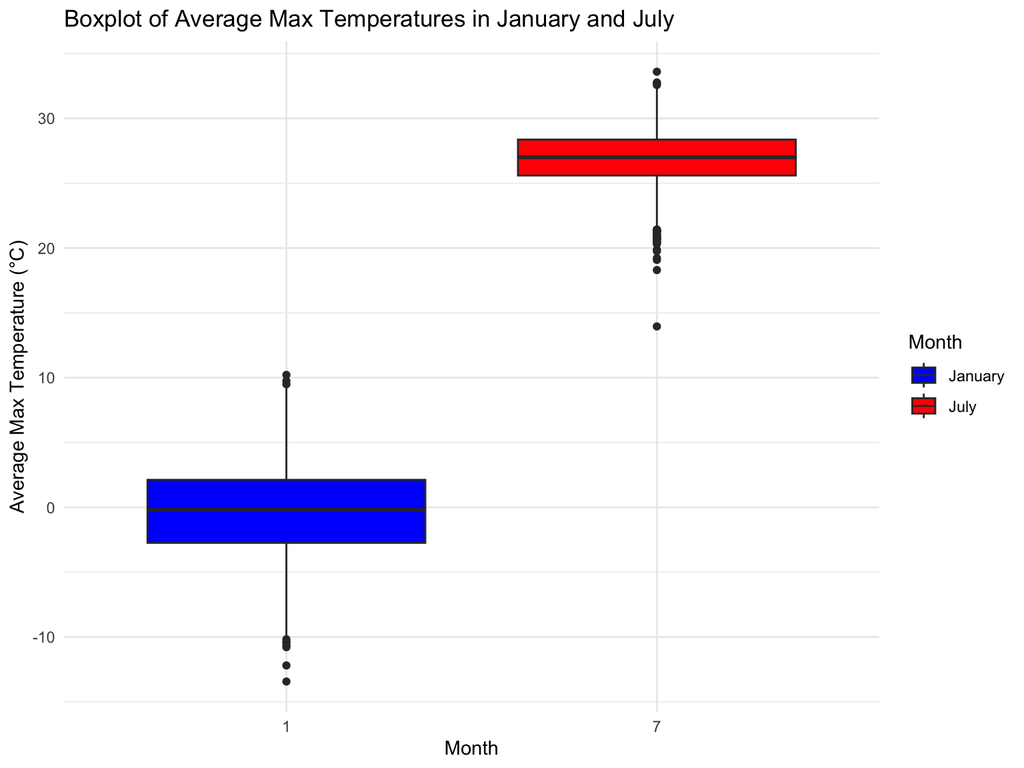

```r
avg_temp <- ny_noaa %>%
  filter(month %in% c(1, 7)) %>%
  group_by(id, year, month) %>%
  summarize(avg_tmax = mean(tmax, na.rm = TRUE), .groups = 'drop')


ggplot(avg_temp, aes(x = as.factor(month), y = avg_tmax, fill = as.factor(month))) +
  geom_boxplot() +
  scale_fill_manual(values = c("blue", "red"),
                    labels = c("January", "July")) +
  labs(title = "Boxplot of Average Max Temperatures in January and July",
       x = "Month",
       y = "Average Max Temperature (°C)",
       fill = "Month") +
  theme_minimal()
```

The plots for both January and July appear approximately normally distributed. The average max temperatures are higher July (median of 27 degrees Celsius), compared to January (median of 0 degrees Celsius), which is expected. There is less variability in temperatures for July since the size of the box (i.e., interquartile range) is smaller compared to the box for January. There is more variability in extreme temperature values in January since the whiskers are longer. There appears to be a few outliers in box January and July which indicate the presence of extreme weather events.

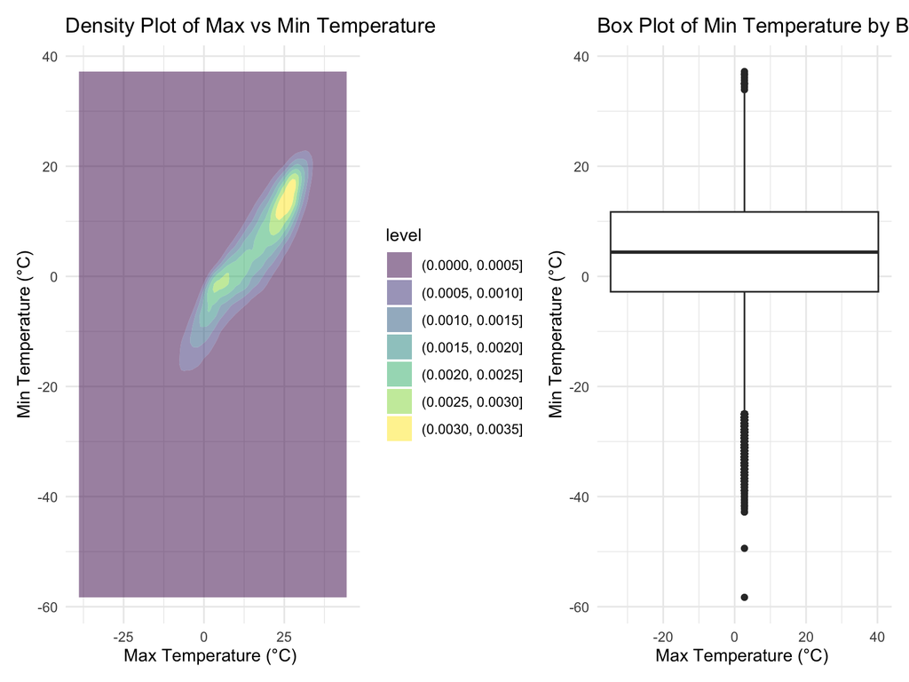

```r
ny_noaa <- na.omit(ny_noaa)

density_plot<-ggplot(ny_noaa, aes(x = tmax, y = tmin)) +
  geom_density_2d_filled(alpha = 0.5) +
  labs(title = "Density Plot of Max vs Min Temperature",
       x = "Max Temperature (°C) ",
       y = "Min Temperature (°C)") +
  theme_minimal()

box_plot <- ggplot(ny_noaa, aes(x = tmax, y = tmin)) +
  geom_boxplot() +
  labs(title = "Box Plot of Min Temperature by Binned Max Temperature",
       x = "Max Temperature (°C) ",
       y = "Min Temperature (°C)") +
  theme_minimal()

density_plot + box_plot
```

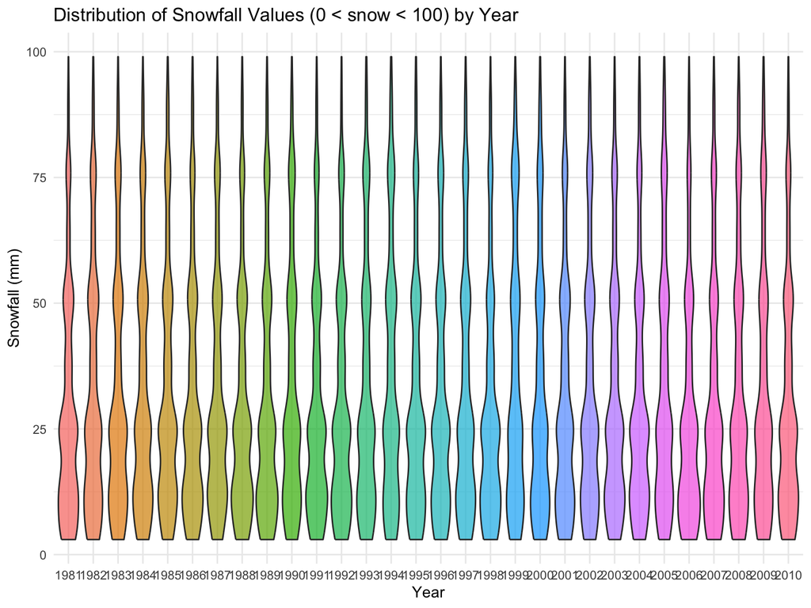

```r
filtered_snow <- ny_noaa %>%
  filter(snow > 0 & snow < 100)


snowfall_plot_violin <- ggplot(filtered_snow, aes(x = factor(year), y = snow, fill = factor(year))) +
  geom_violin(alpha = 0.7) +
  labs(title = "Distribution of Snowfall Values (0 < snow < 100) by Year",
       x = "Year",
       y = "Snowfall (mm)",
       fill = "Year") +
  theme_minimal() +
  theme(legend.position = "none")

print(snowfall_plot_violin)
```

### Problem 2

#### Reading in the data, cleaning, and merging datasets

```r
covar <- read.csv("./data/nhanes_covar.csv", skip = 4) %>%
  janitor::clean_names() %>%
  filter(age >= 21, !is.na(seqn)) %>%
  mutate(
    sex = factor(sex, levels = c(1, 2), labels = c("Male", "Female")),
    education = factor(education, levels = c(1, 2, 3), labels = c("Less than high school", "High school equivalent", "More than high school"))
  )

accel <- read.csv("./data/nhanes_accel.csv", na.strings = c("NA", "", ".")) %>%
  janitor::clean_names()%>%
  pivot_longer(
   starts_with("min"), names_to = "minutes", values_to = "min", names_prefix ="min")

fas_df =
  full_join(covar, accel, by = "seqn")%>%
  drop_na()

head(fas_df,5)
```

```
##    seqn  sex age  bmi              education minutes       min
## 1 62161 Male  22 23.3 High school equivalent       1 1.1060000
## 2 62161 Male  22 23.3 High school equivalent       2 3.1151667
## 3 62161 Male  22 23.3 High school equivalent       3 1.4675000
## 4 62161 Male  22 23.3 High school equivalent       4 0.9376667
## 5 62161 Male  22 23.3 High school equivalent       5 1.5986667
```

```r
library(knitr)

education_summary <- fas_df %>%
  group_by(education, sex) %>%
  summarise(count = n(), .groups = "drop") %>%
  pivot_wider(names_from = sex, values_from = count, values_fill = list(count = 0))%>%
  as.data.frame()

knitr::kable(education_summary, col.names = c("Education", "Males","Females"), caption = "Education Levels by Sex")
```

Education Levels by Sex

| Education | Males | Females |
| --- | --- | --- |
| Less than high school | 38880 | 40320 |
| High school equivalent | 50400 | 33120 |
| More than high school | 80640 | 84960 |

This table shows education levels for males and females. For the category of more than high school and less than high school, the number of males and females is similar. However, for high school equivalent, there are more men in this category compared to females.

#### Visualization of Age Distributions

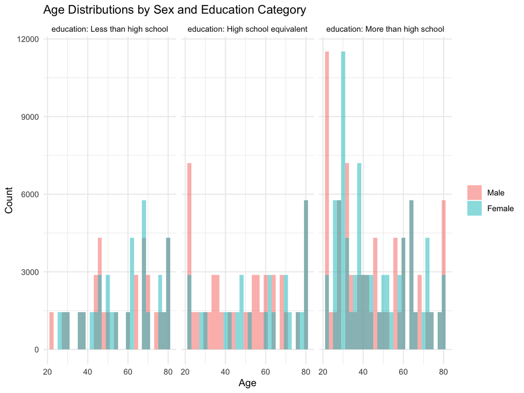

```r
agedistribution_histogram <- ggplot(fas_df, aes(x = age, fill = sex)) +
  geom_histogram(position = "identity", alpha = 0.5, binwidth = 2) +
  facet_wrap(~ education, labeller = label_both) +
  labs(title = "Age Distributions by Sex and Education Category",
       x = "Age",
       y = "Count") +
  theme_minimal() +
  theme(legend.title = element_blank())

print(agedistribution_histogram)
```

```r
total_activity <- fas_df %>%
  group_by(seqn, sex, age, education) %>%
  summarize(total_activity = sum(min, na.rm = TRUE), .groups = "drop")


fas_df <- fas_df %>%
  left_join(total_activity, by = c("seqn", "sex", "age", "education"))

print(head(fas_df))
```

```
##    seqn  sex age  bmi              education minutes       min total_activity
## 1 62161 Male  22 23.3 High school equivalent       1 1.1060000       13194.09
## 2 62161 Male  22 23.3 High school equivalent       2 3.1151667       13194.09
## 3 62161 Male  22 23.3 High school equivalent       3 1.4675000       13194.09
## 4 62161 Male  22 23.3 High school equivalent       4 0.9376667       13194.09
## 5 62161 Male  22 23.3 High school equivalent       5 1.5986667       13194.09
## 6 62161 Male  22 23.3 High school equivalent       6 0.1453333       13194.09
```

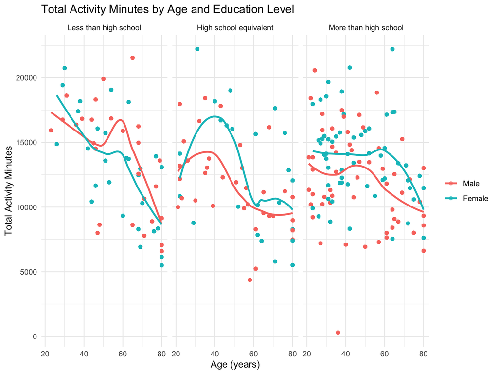

```r
activity_plot <- ggplot(fas_df, aes(x = age, y = total_activity, color = sex)) +
  geom_point(alpha = 0.6) +
  geom_smooth(method = "loess", se = FALSE) +
  labs(title = "Total Activity Minutes by Age and Education Level",
       x = "Age (years)",
       y = "Total Activity Minutes") +
  facet_wrap(~ education) +
  theme_minimal() +
  theme(legend.title = element_blank())

# Display the plot
print(activity_plot)
```

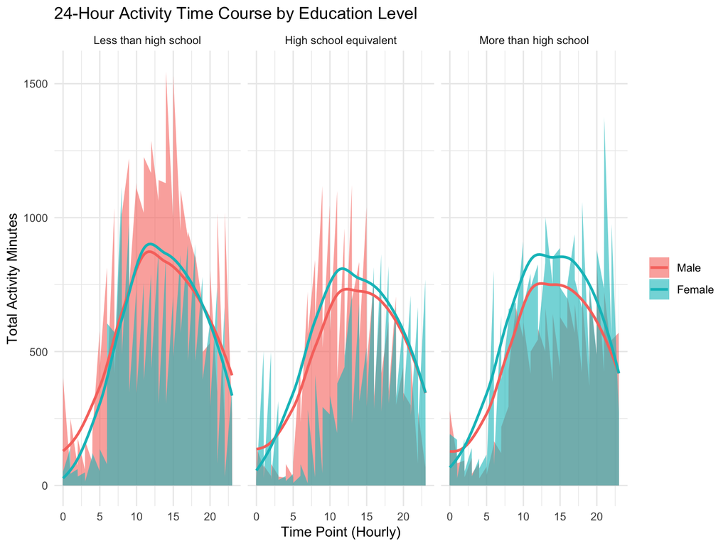

```r
hour_activity <- fas_df %>%
   mutate(minutes = as.numeric(as.character(minutes)),
   hour= floor(minutes/60),
        hour = ifelse(hour>23, 23, hour)) %>%
  group_by(seqn, sex, education, hour)%>%
  summarize(total_activity = sum(min, na.rm = TRUE), .groups = "drop")


activity_plot <- ggplot(hour_activity, aes(x = hour, y = total_activity, fill= sex)) +
  geom_area(position = "identity", alpha = 0.6, color = NA)+
  geom_smooth(aes(color = sex), method = "loess", se = FALSE, size = 1) +
  labs(title = "24-Hour Activity Time Course by Education Level",
       x = "Time Point (Hourly)",
       y = "Total Activity Minutes") +
  facet_wrap(~ education)+
  theme_minimal() +
  theme(legend.title = element_blank())

print(activity_plot)
```

### Problem 3

```r
Jan_2020 <- read.csv("./data/Jan 2020 Citi.csv") %>%
  janitor::clean_names() %>%
  rename(duration_minutes = duration) %>%
  rename(membership_type = member_casual) %>%
  rename(ride_type = rideable_type) %>%
  mutate(Date = "January 2020")

Jan_2024 <- read.csv("./data/Jan 2024 Citi.csv") %>%
  janitor::clean_names() %>%
  rename(duration_minutes = duration) %>%
  rename(membership_type = member_casual) %>%
  rename(ride_type = rideable_type) %>%
  mutate(Date = "January 2024")

July_2020 <- read.csv("./data/July 2020 Citi.csv") %>%
  janitor::clean_names() %>%
  rename(duration_minutes = duration) %>%
  rename(membership_type = member_casual) %>%
  rename(ride_type = rideable_type) %>%
  mutate(Date = "July 2020")

July_2024 <- read.csv("./data/July 2024 Citi.csv") %>%
  janitor::clean_names() %>%
  rename(duration_minutes = duration) %>%
  rename(membership_type = member_casual) %>%
  rename(ride_type = rideable_type) %>%
  mutate(Date = "July 2024")

combined_data <- bind_rows(Jan_2020, Jan_2024, July_2020, July_2024)
head(combined_data, 5)
```

```
##            ride_id    ride_type  weekdays duration_minutes
## 1 4BE06CB33B037044 classic_bike   Tuesday        15.333267
## 2 26886E034974493B classic_bike Wednesday         5.309467
## 3 24DC56060EBE6260 classic_bike    Friday         9.691800
## 4 EEDC1053582D02E5 classic_bike    Sunday         6.996183
## 5 2CD4BD4CEE2E50A9 classic_bike    Friday         2.849500
##           start_station_name        end_station_name membership_type
## 1     Columbus Ave & W 95 St   E 53 St & Madison Ave          member
## 2            2 Ave & E 96 St        1 Ave & E 110 St          member
## 3 Columbia St & Rivington St Grand St & Elizabeth St          member
## 4     W 84 St & Columbus Ave  Columbus Ave & W 72 St          member
## 5     Forsyth St & Broome St Suffolk St & Stanton St          member
##           Date
## 1 January 2020
## 2 January 2020
## 3 January 2020
## 4 January 2020
## 5 January 2020
```

The combined data set provides information on Citi Bike utilization in New York City for January 2020, January 2024, July 2020, and July 2024, and contains 99485 observations and 8 variables.The variable names include ride_id, ride_type, weekdays, duration_minutes, start_station_name, end_station_name, membership_type, and date. Each dataset had the same column names so they were combined using the bind rows option. Some of the original variables (duration, member_casual, and rideable_type” were renamed for clarity purposes. In the dataset, there were no missing (NA values) for any variable except for start_station_name.

```r
combined_table<-combined_data  %>%
  group_by(Date, membership_type)%>%
  summarize(total_rides = n(), .groups = 'drop')%>%
  arrange(Date, membership_type)%>%
  pivot_wider(names_from = membership_type, values_from = total_rides)%>%
  as.data.frame()

  print(combined_table)
```

```
##           Date casual member
## 1 January 2020    984  11436
## 2 January 2024   2108  16753
## 3    July 2020   5637  15411
## 4    July 2024  10894  36262
```

```r
  knitr::kable(combined_table, col.names = c("Date", "Casual","Member"), caption = "Number of Citi Bike Members, by Year and Date")
```

Number of Citi Bike Members, by Year and Date

| Date | Casual | Member |
| --- | --- | --- |
| January 2020 | 984 | 11436 |
| January 2024 | 2108 | 16753 |
| July 2020 | 5637 | 15411 |
| July 2024 | 10894 | 36262 |

These results show that the total number of rides was highest in July 2024 for both casual and member riders. The lowest total number or rides was January 2020 for both type. This also signifies that with time, the total number of rides for casual rider and Citi Bike member utilization has risen.

```r
popular_stations<-combined_data  %>%
  filter(Date=="July 2024")  %>%
  group_by (start_station_name)  %>%
  summarize(num_rides =n()) %>%
  arrange(desc(num_rides)) %>%
  slice_head(n=5) %>%
  as.data.frame()

print(popular_stations)
```

```
##         start_station_name num_rides
## 1 Pier 61 at Chelsea Piers       163
## 2  University Pl & E 14 St       155
## 3          W 21 St & 6 Ave       152
## 4    West St & Chambers St       150
## 5          W 31 St & 7 Ave       146
```

The 5 most popular starting stations were Pier 61, University Place, W 21 St & 6 Ave, West St & Chambers St, and W 31 St & 7th Ave. Pier 61 at Chelsea Piers had the highest number of rides.

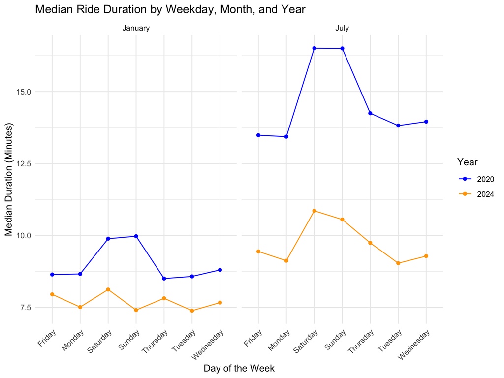

```r
median_duration <- combined_data %>%
  group_by(weekdays, Date) %>%
  summarize(median_duration = median(duration_minutes, na.rm = TRUE), .groups = 'drop') %>%
  separate(Date, into = c("month", "year"), sep = " ", convert = TRUE) %>%
  mutate(year = as.factor(year))

ggplot(median_duration, aes(x=weekdays, y=median_duration, color = year))+ geom_point()+
  geom_line(aes(group = year))+
  facet_wrap(~month)+
  labs (title = "Median Ride Duration by Weekday, Month, and Year", x = "Day of the Week", y = "Median Duration (Minutes)",
        color = "Year") +
  scale_color_manual(values = c("2020" = "blue", "2024" = "orange")) +
  theme_minimal() +
  theme(axis.text.x = element_text(angle = 45, hjust = 1))
```

This plot shows the effects of the day of the week, month, and year on median ride duration. This plot shows that in January 2020, median ride duration was higher compared to January 2024 with the peak weekdays for 2020 being Saturday and Sunday. For July, the highest median duration was in July 2020 compared to July 2024 with the peak weekdays also being the weekend.

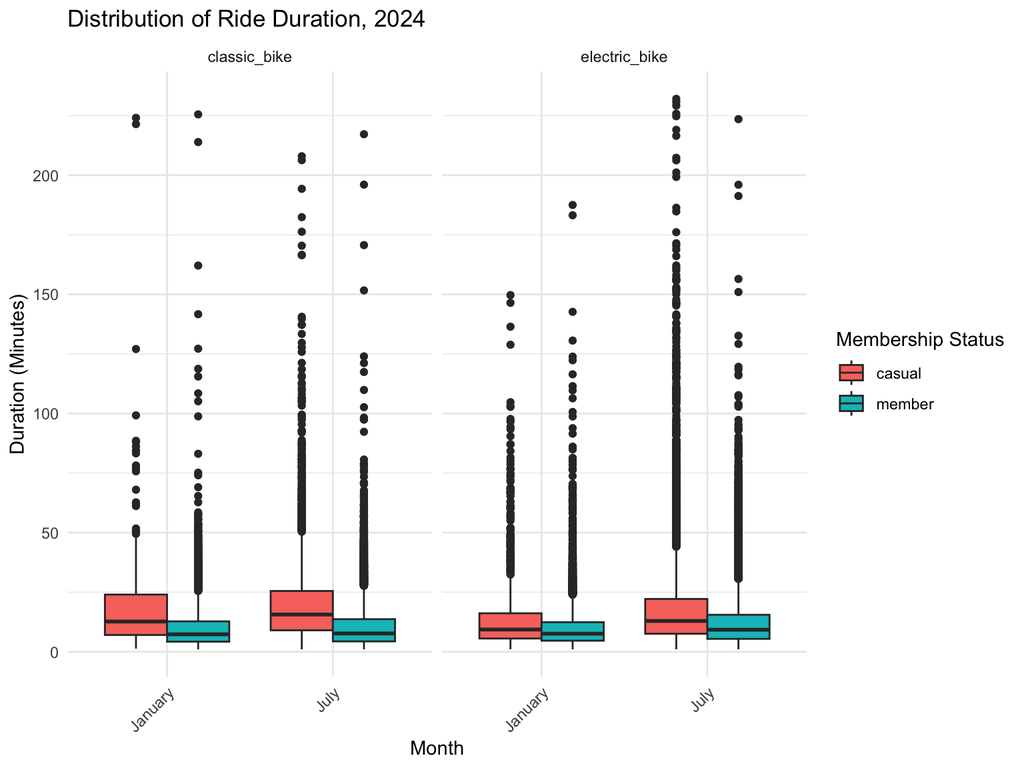

```r
year_2024 <- combined_data %>%
  filter (grepl("2024", Date)) %>%
  separate(Date, into = c("month", "year"), sep = " ", convert = TRUE)

ggplot(year_2024, aes(x = month, y = duration_minutes, fill = membership_type)) +
  geom_boxplot(position = "dodge") +
  facet_wrap(~ ride_type) +
  labs(title = "Distribution of Ride Duration, 2024",
       x = "Month",
       y = "Duration (Minutes)",
       fill = "Membership Status") +
  theme_minimal() +
  theme(axis.text.x = element_text(angle = 45, hjust = 1))
```